# scSensitiveGene_Manual

Zechuan Chen

2021/3/5

## R package install

Before install `scSensitiveGeneDefine`, please install the `Seurat`,`DoubletFinder`,`entropy` and `dplyr`.

```r
devtools::install_github("Zechuan-Chen/scSensitiveGeneDefine")
library(scSensitiveGeneDefine)
```

## Data download

1. You can get the common data from the https://support.10xgenomics.com/single-cell-gene-expression/datasets/
2. The function `runSeurat` can be used to deal with the raw data, which can be download from the above link.

```r
object<-runSeurat(data.dir="~/outs/filtered_feature_bc_matrix/",
                       sample_name = "scRNA-seq Sample 1",
                       PC = 40,
                       resolution = 0.6,
                       mt.cut_off = 20,
                       min_nFeature.cut_off = 200,
                       data_type = "Expression_matrix",
                       filter_doublet = T,
                       algorithm = 1)
```

## High variable genes statistic

1. Statistics on high variable genes of each subclusters
2. The result will be used for sensitive genes defination.
3. The example data `PBMC` can be load by `data(PBMC)`. The example data can be get from the 10x Genomics Support

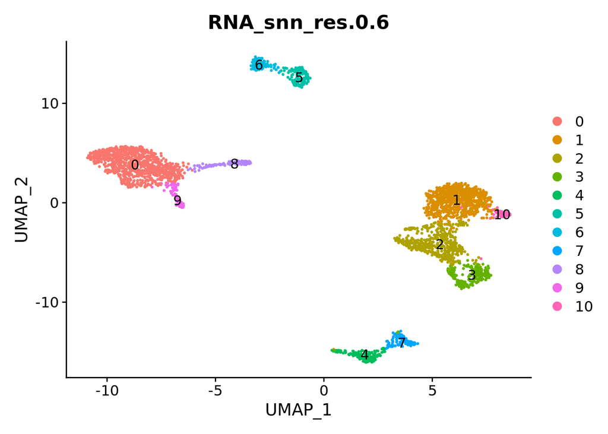

```r
library(Seurat)
library(scSensitiveGeneDefine)
data(PBMC)
Idents(PBMC)<-"RNA_snn_res.0.6"
Seurat::DimPlot(PBMC,label=T,group.by = "RNA_snn_res.0.6")
```

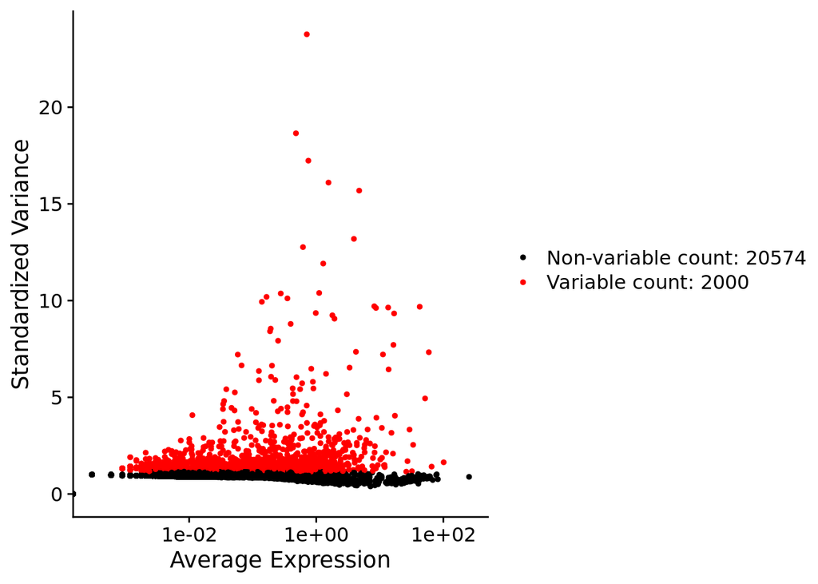

```r
Seurat::VariableFeaturePlot(PBMC)
```

```r
HVG_Anno<-HVG_Statistic(PBMC,First_time_unsupervised_clustering_label = "RNA_snn_res.1")
```

## Caculate the entroy of each genes for sensitive genes identification

1. Screening for sensitive genes based on the CV Ranking and Shannon Index

```r
SensitiveGene<-GetSensitivegene(PBMC,HVG_Anno = HVG_Anno)
```

```
## Finished averaging RNA for cluster 0
```

```
## Finished averaging RNA for cluster 1
```

```
## Finished averaging RNA for cluster 2
```

```
## Finished averaging RNA for cluster 3
```

```
## Finished averaging RNA for cluster 4
```

```
## Finished averaging RNA for cluster 5
```

```
## Finished averaging RNA for cluster 6
```

```
## Finished averaging RNA for cluster 7
```

```
## Finished averaging RNA for cluster 8
```

```
## Finished averaging RNA for cluster 9
```

```
## Finished averaging RNA for cluster 10
```

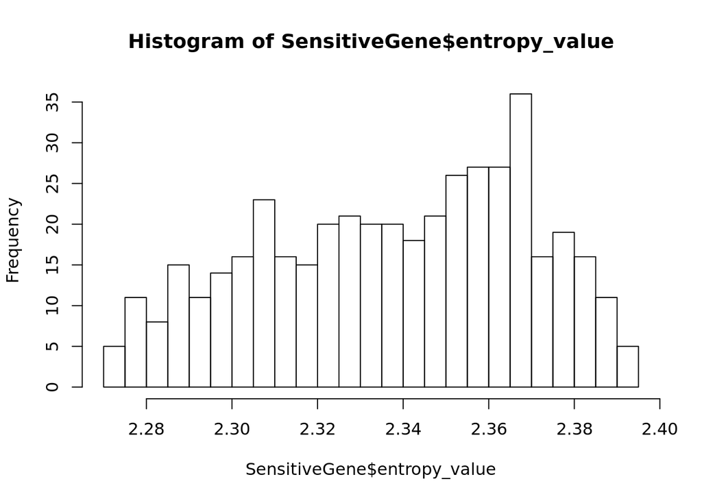

```r
hist(SensitiveGene$entropy_value,breaks = 20)
```

## Remove sensitive genes from variable Features 1. Only removing the sensitive genes from the variable features, not transcriptome. In this way, the unsupervised clustering result will be improved with transcript no change. 2. Some red points transform to be the black points. These points represent the sensitive genes in this data.

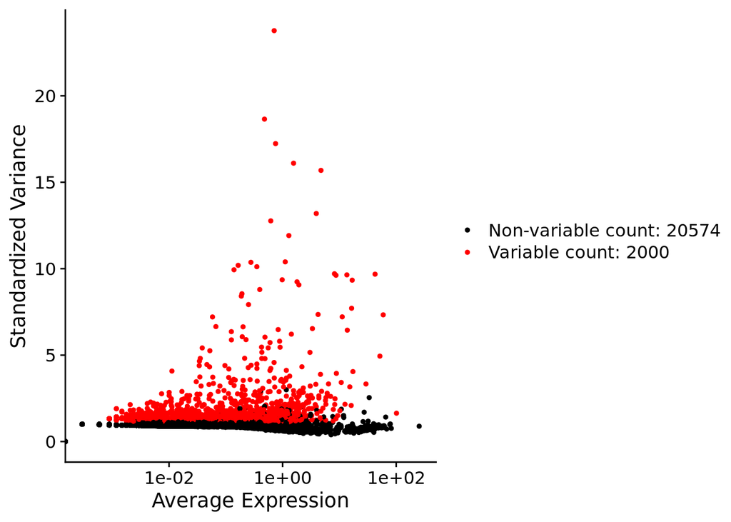

```r
PBMC<-ReSelectVariableFeatures(PBMC,SensitiveGene = SensitiveGene)
VariableFeaturePlot(PBMC)
```

## Reclustering after removing sensitive genes 1. After removing the sensitive gene, reclusering the single-cell data.

```r
PBMC2<-ReClustering(PBMC)
```

```
## Modularity Optimizer version 1.3.0 by Ludo Waltman and Nees Jan van Eck
##
## Number of nodes: 3384
## Number of edges: 177311
##
## Running Louvain algorithm...
## Maximum modularity in 10 random starts: 0.8715
## Number of communities: 11
## Elapsed time: 0 seconds
```

```
## 21:34:40 Found 3 connected components, falling back to 'spca' initialization with init_sdev = 1
## 21:34:40 PCA: 2 components explained 61.48% variance
```

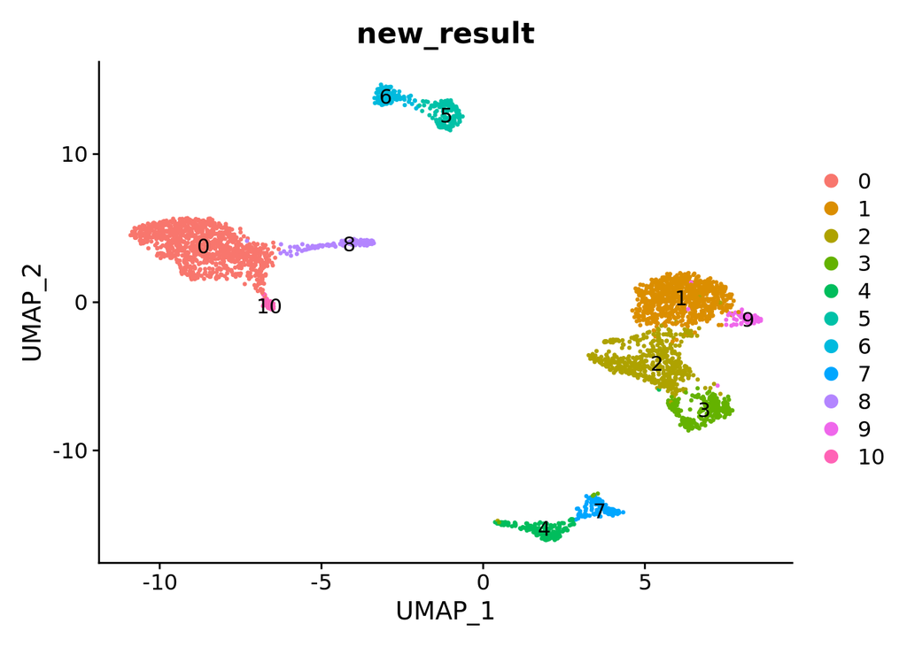

```r
PBMC$new_result<-PBMC2$RNA_snn_res.0.6
Seurat::DimPlot(PBMC,label=T,group.by = "new_result")
```